# Multiple Regression

Multiple Regression

[Download materials](https://github.com/HSL-Data/BIMS_8382_Web/blob/master/public/zips/mult_regression.zip?raw=true)

## Multiple Regression

Today we are going to be looking at cases where the outcome can not be explained by one variable alone.

```r
library(tidyverse)
library(broom)
library(modelr)
#install.packages("MASS")
library(MASS)
#install.packages("dotwhisker")
library(dotwhisker)  # for visualizing regression results
```

We are going to read in Life Expectancy data for countries over time.

“The Global Health Observatory (GHO) data repository under World Health Organization (WHO) keeps track of the health status as well as many other related factors for all countries. The dataset related to life expectancy, health factors for 193 countries has been collected from the same WHO data repository website and its corresponding economic data was collected from United Nation website. Among all categories of health-related factors only those critical factors were chosen which are more representative.”

```r
le <- read_csv("Life Expectancy Data.csv")
#Need to clean up the variable names to make it easier to work with
names(le) <- str_replace_all(names(le), " ", "_")
names(le) <- str_replace_all(names(le), "-", "_")
names(le) <- str_replace_all(names(le), "/", "_")

#Let's take a quick look at our Outcome Variable, Life Expectancy
summary(le$Life_expectancy)
```

```
##    Min. 1st Qu.  Median    Mean 3rd Qu.    Max.    NA's
##   36.30   63.10   72.10   69.22   75.70   89.00      10
```

```r
#Since Life Expectancy is our outcome variable, we don't want any missing values in that column.
le <- le %>% drop_na(Life_expectancy)
```

# Exploring the Dataset

Let’s start by exploring the distribution of the `Life_expectancy` variable and possible other variables of interest.

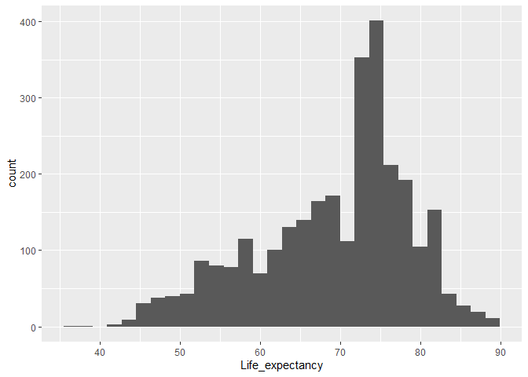

```r
le %>%
ggplot(aes(x = Life_expectancy)) + geom_histogram()
```

Average life expectancy appears to peak around the mid-70s, with some country-years having much lower values.

Let’s now start to explore Life Expectancy vs. other possible important variables

```r
names(le)
```

```
##  [1] "Country"                         "Year"
##  [3] "Status"                          "Life_expectancy"
##  [5] "Adult_Mortality"                 "infant_deaths"
##  [7] "Alcohol"                         "percentage_expenditure"
##  [9] "Hepatitis_B"                     "Measles"
## [11] "BMI"                             "under_five_deaths"
## [13] "Polio"                           "Total_expenditure"
## [15] "Diphtheria"                      "HIV_AIDS"
## [17] "GDP"                             "Population"
## [19] "thinness__1_19_years"            "thinness_5_9_years"
## [21] "Income_composition_of_resources" "Schooling"
```

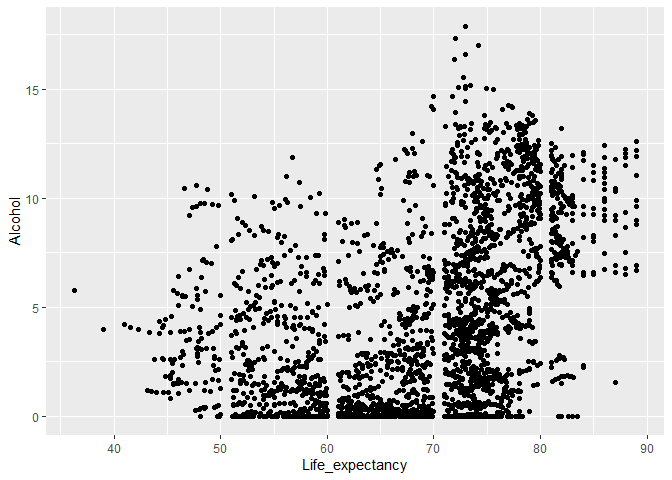

```r
# Life Expectancy vs. Alcohol Use
le %>%
ggplot(aes(x = Life_expectancy, y = Alcohol)) + geom_point()
```

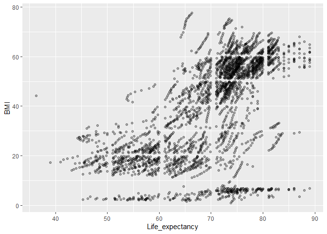

```r
# Possible upward trend here.

# Life Expectancy vs. BMI
le %>%
ggplot(aes(x = Life_expectancy, y = BMI)) + geom_point(alpha = .3)
```

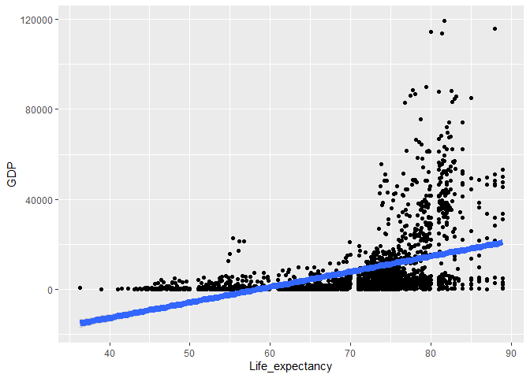

```r
# Another upward trend

#  GDP
le %>%
ggplot(aes(x = Life_expectancy, y = GDP)) + geom_point() + geom_smooth(method = "lm", lwd = 3)
```

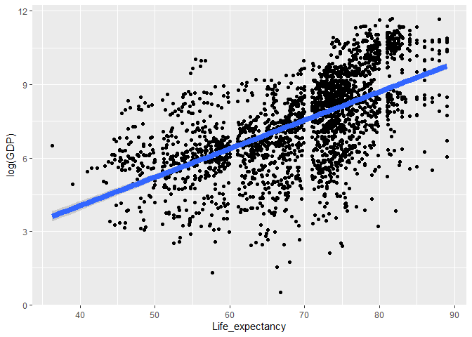

```r
le %>%
ggplot(aes(x = Life_expectancy, y = log(GDP))) + geom_point() + geom_smooth(method = "lm", lwd = 3)
```

```r
# Another upward trend
```

So far it appears that as BMI, GDP, and Alcohol use increase, so does Life Expectancy. Obviously, there are probably a lot more variables at play here.

One variable that might have an impact could be the status of the country, whether it is considered Developing or Developed.

We now need to look at the `Status` variable, as we did the others.

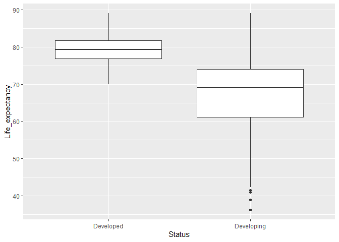

```r
le %>%
  ggplot(aes(x = Status, y = Life_expectancy)) + geom_boxplot()
```

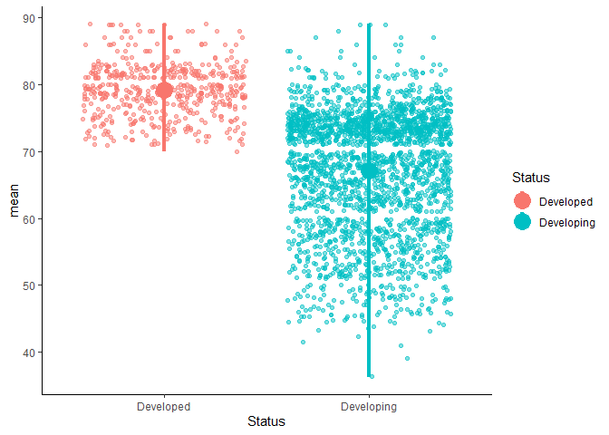

```r
le %>%
  group_by(Status) %>%
  summarize(min = min(Life_expectancy),
            max = max(Life_expectancy),
            mean = mean(Life_expectancy)) %>%
  ggplot(aes(x = Status, y = mean, color = Status)) +
  geom_pointrange(aes(ymin = min, ymax = max), size = 1.5) +
  geom_jitter(data = le, aes(x = Status, y = Life_expectancy), alpha = .5) +
  theme_classic()
```

Looking at the Development Status of the country, it appears this is something we need to take into account.

Let’s add Status to the graphs to see what our data looks like

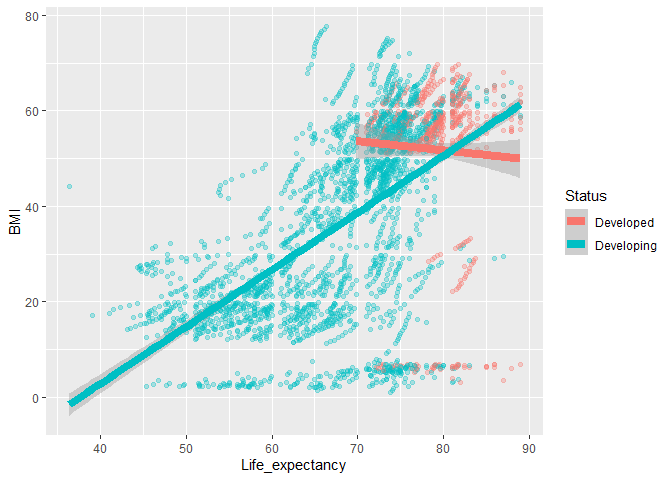

```r
le %>%
ggplot(aes(x = Life_expectancy, y = BMI, color = Status)) + geom_point(alpha = .3) + geom_smooth(method = "lm", lwd = 3)
```

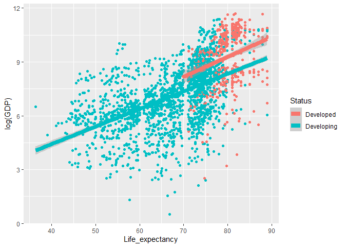

```r
# Interesting Difference in the effect of BMI on Developing vs. Developed Countries

le %>% ggplot(aes(x = Life_expectancy, y = log(GDP), color = Status)) + geom_point() + geom_smooth(method = "lm", lwd = 3)
```

```r
# Effect of GDP appears to be similar between Developing and Developed countries
```

## Interactions

As we saw when looking at the previous graphs, sometimes a variable will a differential effect on another variable and sometimes it does not. This is when we need to investigate whether we want to use an interaction term so that different groups have different slopes.

```r
# Let's start with a basic model looking at BMI and Life Expectancy
mod0 <- lm(Life_expectancy ~ BMI, data = le)

# This is a self-created function that will run through a bunch of the model checks that we normally run. We will do this a bunch of times today, so a function will allow us to save some time.

modCheck <- function(mod) {
 print(summary(mod))
 print(tidy(mod))
 print(glance(mod))
}
modCheck(mod0)
```

```
##
## Call:
## lm(formula = Life_expectancy ~ BMI, data = le)
##
## Residuals:
##     Min      1Q  Median      3Q     Max
## -34.660  -4.663   0.353   4.466  28.105
##
## Coefficients:
##              Estimate Std. Error t value Pr(>|t|)
## (Intercept) 59.032496   0.313745   188.2   <2e-16 ***
## BMI          0.269858   0.007274    37.1   <2e-16 ***
## ---
## Signif. codes:  0 '***' 0.001 '**' 0.01 '*' 0.05 '.' 0.1 ' ' 1
##
## Residual standard error: 7.812 on 2894 degrees of freedom
##   (32 observations deleted due to missingness)
## Multiple R-squared:  0.3223, Adjusted R-squared:  0.322
## F-statistic:  1376 on 1 and 2894 DF,  p-value: < 2.2e-16
##
## # A tibble: 2 x 5
##   term        estimate std.error statistic   p.value
##   <chr>          <dbl>     <dbl>     <dbl>     <dbl>
## 1 (Intercept)   59.0     0.314       188.  0.
## 2 BMI            0.270   0.00727      37.1 8.92e-247
## # A tibble: 1 x 12
##   r.squared adj.r.squared sigma statistic   p.value    df  logLik    AIC    BIC
##       <dbl>         <dbl> <dbl>     <dbl>     <dbl> <dbl>   <dbl>  <dbl>  <dbl>
## 1     0.322         0.322  7.81     1376. 8.92e-247     1 -10062. 20129. 20147.
## # ... with 3 more variables: deviance <dbl>, df.residual <int>, nobs <int>
```

BMI is definitely a worthwhile variable to keep in mind, however when we looked at the graph earlier, BMI had a differential effect on the Development Status of the country.

```r
mod1 <- lm(Life_expectancy ~ BMI + Status, data = le)
modCheck(mod1)
```

```
##
## Call:
## lm(formula = Life_expectancy ~ BMI + Status, data = le)
##
## Residuals:
##     Min      1Q  Median      3Q     Max
## -32.886  -4.327   0.466   4.153  22.072
##
## Coefficients:
##                  Estimate Std. Error t value Pr(>|t|)
## (Intercept)      67.82133    0.48531  139.75   <2e-16 ***
## BMI               0.21961    0.00707   31.06   <2e-16 ***
## StatusDeveloping -8.34238    0.36981  -22.56   <2e-16 ***
## ---
## Signif. codes:  0 '***' 0.001 '**' 0.01 '*' 0.05 '.' 0.1 ' ' 1
##
## Residual standard error: 7.205 on 2893 degrees of freedom
##   (32 observations deleted due to missingness)
## Multiple R-squared:  0.4237, Adjusted R-squared:  0.4233
## F-statistic:  1063 on 2 and 2893 DF,  p-value: < 2.2e-16
##
## # A tibble: 3 x 5
##   term             estimate std.error statistic   p.value
##   <chr>               <dbl>     <dbl>     <dbl>     <dbl>
## 1 (Intercept)        67.8     0.485       140.  0.
## 2 BMI                 0.220   0.00707      31.1 4.43e-183
## 3 StatusDeveloping   -8.34    0.370       -22.6 6.19e-104
## # A tibble: 1 x 12
##   r.squared adj.r.squared sigma statistic p.value    df logLik    AIC    BIC
##       <dbl>         <dbl> <dbl>     <dbl>   <dbl> <dbl>  <dbl>  <dbl>  <dbl>
## 1     0.424         0.423  7.21     1063.       0     2 -9827. 19662. 19686.
## # ... with 3 more variables: deviance <dbl>, df.residual <int>, nobs <int>
```

```r
mod2 <- lm(Life_expectancy ~ BMI * Status, data = le)
modCheck(mod2)
```

```
##
## Call:
## lm(formula = Life_expectancy ~ BMI * Status, data = le)
##
## Residuals:
##     Min      1Q  Median      3Q     Max
## -33.233  -4.142   0.532   3.751  23.195
##
## Coefficients:
##                       Estimate Std. Error t value Pr(>|t|)
## (Intercept)           79.71844    0.97990   81.35   <2e-16 ***
## BMI                   -0.01005    0.01795   -0.56    0.576
## StatusDeveloping     -21.62041    1.02425  -21.11   <2e-16 ***
## BMI:StatusDeveloping   0.26875    0.01942   13.84   <2e-16 ***
## ---
## Signif. codes:  0 '***' 0.001 '**' 0.01 '*' 0.05 '.' 0.1 ' ' 1
##
## Residual standard error: 6.979 on 2892 degrees of freedom
##   (32 observations deleted due to missingness)
## Multiple R-squared:  0.4594, Adjusted R-squared:  0.4589
## F-statistic: 819.4 on 3 and 2892 DF,  p-value: < 2.2e-16
##
## # A tibble: 4 x 5
##   term                 estimate std.error statistic  p.value
##   <chr>                   <dbl>     <dbl>     <dbl>    <dbl>
## 1 (Intercept)           79.7       0.980     81.4   0.
## 2 BMI                   -0.0100    0.0180    -0.560 5.76e- 1
## 3 StatusDeveloping     -21.6       1.02     -21.1   4.17e-92
## 4 BMI:StatusDeveloping   0.269     0.0194    13.8   3.26e-42
## # A tibble: 1 x 12
##   r.squared adj.r.squared sigma statistic p.value    df logLik    AIC    BIC
##       <dbl>         <dbl> <dbl>     <dbl>   <dbl> <dbl>  <dbl>  <dbl>  <dbl>
## 1     0.459         0.459  6.98      819.       0     3 -9734. 19478. 19508.
## # ... with 3 more variables: deviance <dbl>, df.residual <int>, nobs <int>
```

```r
# Adding an interaction term does appear to improve the model.
anova(mod1, mod2)
```

```
## Analysis of Variance Table
##
## Model 1: Life_expectancy ~ BMI + Status
## Model 2: Life_expectancy ~ BMI * Status
##   Res.Df    RSS Df Sum of Sq      F    Pr(>F)
## 1   2893 150202
## 2   2892 140875  1    9327.2 191.48 < 2.2e-16 ***
## ---
## Signif. codes:  0 '***' 0.001 '**' 0.01 '*' 0.05 '.' 0.1 ' ' 1
```

Let’s try the same thing with GDP

```r
mod3 <- lm(Life_expectancy ~ log(GDP) + Status, data = le)
mod4 <- lm(Life_expectancy ~ log(GDP) * Status, data = le)
modCheck(mod3)
```

```
##
## Call:
## lm(formula = Life_expectancy ~ log(GDP) + Status, data = le)
##
## Residuals:
##      Min       1Q   Median       3Q      Max
## -29.4264  -4.0440   0.8016   4.8211  24.4051
##
## Coefficients:
##                  Estimate Std. Error t value Pr(>|t|)
## (Intercept)      56.92616    0.87465   65.08   <2e-16 ***
## log(GDP)          2.44072    0.08711   28.02   <2e-16 ***
## StatusDeveloping -7.05388    0.42567  -16.57   <2e-16 ***
## ---
## Signif. codes:  0 '***' 0.001 '**' 0.01 '*' 0.05 '.' 0.1 ' ' 1
##
## Residual standard error: 7.337 on 2482 degrees of freedom
##   (443 observations deleted due to missingness)
## Multiple R-squared:  0.422,  Adjusted R-squared:  0.4215
## F-statistic:   906 on 2 and 2482 DF,  p-value: < 2.2e-16
##
## # A tibble: 3 x 5
##   term             estimate std.error statistic   p.value
##   <chr>               <dbl>     <dbl>     <dbl>     <dbl>
## 1 (Intercept)         56.9     0.875       65.1 0.
## 2 log(GDP)             2.44    0.0871      28.0 2.44e-150
## 3 StatusDeveloping    -7.05    0.426      -16.6 1.41e- 58
## # A tibble: 1 x 12
##   r.squared adj.r.squared sigma statistic   p.value    df logLik    AIC    BIC
##       <dbl>         <dbl> <dbl>     <dbl>     <dbl> <dbl>  <dbl>  <dbl>  <dbl>
## 1     0.422         0.422  7.34      906. 3.73e-296     2 -8477. 16962. 16985.
## # ... with 3 more variables: deviance <dbl>, df.residual <int>, nobs <int>
```

```r
modCheck(mod4)
```

```
##
## Call:
## lm(formula = Life_expectancy ~ log(GDP) * Status, data = le)
##
## Residuals:
##      Min       1Q   Median       3Q      Max
## -29.2548  -3.9513   0.7906   4.4266  24.7124
##
## Coefficients:
##                           Estimate Std. Error t value Pr(>|t|)
## (Intercept)                72.4303     2.0875  34.696  < 2e-16 ***
## log(GDP)                    0.7589     0.2234   3.398 0.000691 ***
## StatusDeveloping          -24.6296     2.1952 -11.220  < 2e-16 ***
## log(GDP):StatusDeveloping   1.9743     0.2420   8.157 5.38e-16 ***
## ---
## Signif. codes:  0 '***' 0.001 '**' 0.01 '*' 0.05 '.' 0.1 ' ' 1
##
## Residual standard error: 7.242 on 2481 degrees of freedom
##   (443 observations deleted due to missingness)
## Multiple R-squared:  0.4371, Adjusted R-squared:  0.4364
## F-statistic: 642.1 on 3 and 2481 DF,  p-value: < 2.2e-16
##
## # A tibble: 4 x 5
##   term                      estimate std.error statistic   p.value
##   <chr>                        <dbl>     <dbl>     <dbl>     <dbl>
## 1 (Intercept)                 72.4       2.09      34.7  2.19e-215
## 2 log(GDP)                     0.759     0.223      3.40 6.91e-  4
## 3 StatusDeveloping           -24.6       2.20     -11.2  1.57e- 28
## 4 log(GDP):StatusDeveloping    1.97      0.242      8.16 5.38e- 16
## # A tibble: 1 x 12
##   r.squared adj.r.squared sigma statistic   p.value    df logLik    AIC    BIC
##       <dbl>         <dbl> <dbl>     <dbl>     <dbl> <dbl>  <dbl>  <dbl>  <dbl>
## 1     0.437         0.436  7.24      642. 7.11e-309     3 -8444. 16898. 16927.
## # ... with 3 more variables: deviance <dbl>, df.residual <int>, nobs <int>
```

```r
# Adding an interaction term does appear to improve the model.
anova(mod3, mod4)
```

```
## Analysis of Variance Table
##
## Model 1: Life_expectancy ~ log(GDP) + Status
## Model 2: Life_expectancy ~ log(GDP) * Status
##   Res.Df    RSS Df Sum of Sq     F    Pr(>F)
## 1   2482 133593
## 2   2481 130103  1    3489.4 66.54 5.384e-16 ***
## ---
## Signif. codes:  0 '***' 0.001 '**' 0.01 '*' 0.05 '.' 0.1 ' ' 1
```

Our best, most parsimonious model so far includes Status, GDP and BMI

```r
mod5 <- lm(Life_expectancy ~ BMI * Status + log(GDP), data = le)
modCheck(mod5)
```

```
##
## Call:
## lm(formula = Life_expectancy ~ BMI * Status + log(GDP), data = le)
##
## Residuals:
##     Min      1Q  Median      3Q     Max
## -31.870  -3.687   0.444   3.976  22.923
##
## Coefficients:
##                       Estimate Std. Error t value Pr(>|t|)
## (Intercept)           65.53567    1.27118  51.555   <2e-16 ***
## BMI                   -0.00661    0.01811  -0.365    0.715
## StatusDeveloping     -16.66473    1.07603 -15.487   <2e-16 ***
## log(GDP)               1.54361    0.08519  18.119   <2e-16 ***
## BMI:StatusDeveloping   0.21640    0.01999  10.825   <2e-16 ***
## ---
## Signif. codes:  0 '***' 0.001 '**' 0.01 '*' 0.05 '.' 0.1 ' ' 1
##
## Residual standard error: 6.528 on 2456 degrees of freedom
##   (467 observations deleted due to missingness)
## Multiple R-squared:  0.5421, Adjusted R-squared:  0.5414
## F-statistic:   727 on 4 and 2456 DF,  p-value: < 2.2e-16
##
## # A tibble: 5 x 5
##   term                  estimate std.error statistic  p.value
##   <chr>                    <dbl>     <dbl>     <dbl>    <dbl>
## 1 (Intercept)           65.5        1.27      51.6   0.
## 2 BMI                   -0.00661    0.0181    -0.365 7.15e- 1
## 3 StatusDeveloping     -16.7        1.08     -15.5   1.09e-51
## 4 log(GDP)               1.54       0.0852    18.1   5.76e-69
## 5 BMI:StatusDeveloping   0.216      0.0200    10.8   1.04e-26
## # A tibble: 1 x 12
##   r.squared adj.r.squared sigma statistic p.value    df logLik    AIC    BIC
##       <dbl>         <dbl> <dbl>     <dbl>   <dbl> <dbl>  <dbl>  <dbl>  <dbl>
## 1     0.542         0.541  6.53      727.       0     4 -8107. 16225. 16260.
## # ... with 3 more variables: deviance <dbl>, df.residual <int>, nobs <int>
```

Let’s go wild and add in all of the variables.

```r
modCheck(lm(Life_expectancy ~ ., data = le))
```

```
##
## Call:
## lm(formula = Life_expectancy ~ ., data = le)
##
## Residuals:
##     Min      1Q  Median      3Q     Max
## -5.4860 -0.8103 -0.1556  0.3682  7.6549
##
## Coefficients: (1 not defined because of singularities)
##                                   Estimate Std. Error t value Pr(>|t|)
## (Intercept)                     -3.910e+02  3.428e+01 -11.408  < 2e-16 ***
## CountryAlbania                   1.655e+01  8.573e-01  19.302  < 2e-16 ***
## CountryAlgeria                   1.431e+01  8.499e-01  16.842  < 2e-16 ***
## CountryAngola                   -6.457e+00  8.174e-01  -7.900 5.37e-15 ***
## CountryArgentina                 1.544e+01  1.067e+00  14.469  < 2e-16 ***
## CountryArmenia                   1.487e+01  8.362e-01  17.786  < 2e-16 ***
## CountryAustralia                 2.136e+01  1.302e+00  16.411  < 2e-16 ***
## CountryAustria                   2.237e+01  1.066e+00  20.999  < 2e-16 ***
## CountryAzerbaijan                1.240e+01  8.210e-01  15.106  < 2e-16 ***
## CountryBangladesh                1.094e+01  7.029e-01  15.568  < 2e-16 ***
## CountryBelarus                   1.116e+01  1.001e+00  11.151  < 2e-16 ***
## CountryBelgium                   2.121e+01  1.114e+00  19.043  < 2e-16 ***
## CountryBelize                    1.068e+01  8.444e-01  12.649  < 2e-16 ***
## CountryBenin                     2.957e-01  6.925e-01   0.427 0.669470
## CountryBhutan                    7.148e+00  6.725e-01  10.629  < 2e-16 ***
## CountryBosnia and Herzegovina    1.713e+01  8.902e-01  19.239  < 2e-16 ***
## CountryBotswana                  2.045e+00  8.106e-01   2.523 0.011727 *
## CountryBrazil                    1.385e+01  9.212e-01  15.037  < 2e-16 ***
## CountryBulgaria                  1.420e+01  9.441e-01  15.042  < 2e-16 ***
## CountryBurkina Faso              6.387e-01  8.018e-01   0.797 0.425786
## CountryBurundi                  -9.818e-01  7.320e-01  -1.341 0.180053
## CountryCabo Verde                1.356e+01  7.787e-01  17.415  < 2e-16 ***
## CountryCambodia                  7.090e+00  7.533e-01   9.412  < 2e-16 ***
## CountryCameroon                 -1.240e+00  7.725e-01  -1.606 0.108591
## CountryCanada                    2.272e+01  1.098e+00  20.687  < 2e-16 ***
## CountryCentral African Republic -4.885e+00  8.773e-01  -5.568 3.05e-08 ***
## CountryChad                     -3.978e+00  8.431e-01  -4.718 2.60e-06 ***
## CountryChile                     2.009e+01  1.044e+00  19.249  < 2e-16 ***
## CountryChina                     1.449e+01  1.205e+00  12.023  < 2e-16 ***
## CountryColombia                  1.472e+01  8.387e-01  17.555  < 2e-16 ***
```

[output cut: 135 more lines]

```
##  2 CountryAlbania       16.5      0.857     19.3  2.63e-74
##  3 CountryAlgeria       14.3      0.850     16.8  2.04e-58
##  4 CountryAngola        -6.46     0.817     -7.90 5.37e-15
##  5 CountryArgentina     15.4      1.07      14.5  1.65e-44
##  6 CountryArmenia       14.9      0.836     17.8  2.35e-64
##  7 CountryAustralia     21.4      1.30      16.4  8.74e-56
##  8 CountryAustria       22.4      1.07      21.0  5.15e-86
##  9 CountryAzerbaijan    12.4      0.821     15.1  4.30e-48
## 10 CountryBangladesh    10.9      0.703     15.6  9.22e-51
## # ... with 143 more rows
## # A tibble: 1 x 12
##   r.squared adj.r.squared sigma statistic p.value    df logLik   AIC   BIC
##       <dbl>         <dbl> <dbl>     <dbl>   <dbl> <dbl>  <dbl> <dbl> <dbl>
## 1     0.967         0.964  1.66      295.       0   151 -3100. 6507. 7334.
## # ... with 3 more variables: deviance <dbl>, df.residual <int>, nobs <int>
```

```r
# Probably not a great model. No flexibility whatsoever.
```

Maybe we did some research and found other variables that have tended to heavily influence Life Expectancy. Let’s add them and check on the performance of our model.

```r
mod6 <- lm(Life_expectancy ~ BMI * Status + log(GDP) + Total_expenditure + Income_composition_of_resources + Schooling + Polio + Alcohol, data = le)

modCheck(mod6)
```

```
##
## Call:
## lm(formula = Life_expectancy ~ BMI * Status + log(GDP) + Total_expenditure +
##     Income_composition_of_resources + Schooling + Polio + Alcohol,
##     data = le)
##
## Residuals:
##     Min      1Q  Median      3Q     Max
## -25.860  -2.648   0.447   3.195  27.911
##
## Coefficients:
##                                  Estimate Std. Error t value Pr(>|t|)
## (Intercept)                     47.767539   1.273746  37.502  < 2e-16 ***
## BMI                             -0.010182   0.015753  -0.646    0.518
## StatusDeveloping                -8.821280   0.979154  -9.009  < 2e-16 ***
## log(GDP)                         0.645425   0.079951   8.073 1.10e-15 ***
## Total_expenditure               -0.060314   0.050587  -1.192    0.233
## Income_composition_of_resources 10.594929   0.911318  11.626  < 2e-16 ***
## Schooling                        0.995816   0.066337  15.012  < 2e-16 ***
## Polio                            0.050608   0.005459   9.271  < 2e-16 ***
## Alcohol                         -0.309026   0.038049  -8.122 7.42e-16 ***
## BMI:StatusDeveloping             0.110947   0.017633   6.292 3.74e-10 ***
## ---
## Signif. codes:  0 '***' 0.001 '**' 0.01 '*' 0.05 '.' 0.1 ' ' 1
##
## Residual standard error: 5.43 on 2291 degrees of freedom
##   (627 observations deleted due to missingness)
## Multiple R-squared:  0.6883, Adjusted R-squared:  0.6871
## F-statistic: 562.2 on 9 and 2291 DF,  p-value: < 2.2e-16
##
## # A tibble: 10 x 5
##    term                            estimate std.error statistic   p.value
##    <chr>                              <dbl>     <dbl>     <dbl>     <dbl>
##  1 (Intercept)                      47.8      1.27       37.5   2.08e-240
##  2 BMI                              -0.0102   0.0158     -0.646 5.18e-  1
##  3 StatusDeveloping                 -8.82     0.979      -9.01  4.27e- 19
##  4 log(GDP)                          0.645    0.0800      8.07  1.10e- 15
##  5 Total_expenditure                -0.0603   0.0506     -1.19  2.33e-  1
##  6 Income_composition_of_resources  10.6      0.911      11.6   2.13e- 30
##  7 Schooling                         0.996    0.0663     15.0   1.18e- 48
##  8 Polio                             0.0506   0.00546     9.27  4.11e- 20
##  9 Alcohol                          -0.309    0.0380     -8.12  7.42e- 16
## 10 BMI:StatusDeveloping              0.111    0.0176      6.29  3.74e- 10
## # A tibble: 1 x 12
##   r.squared adj.r.squared sigma statistic p.value    df logLik    AIC    BIC
##       <dbl>         <dbl> <dbl>     <dbl>   <dbl> <dbl>  <dbl>  <dbl>  <dbl>
## 1     0.688         0.687  5.43      562.       0     9 -7153. 14329. 14392.
## # ... with 3 more variables: deviance <dbl>, df.residual <int>, nobs <int>
```

```r
# Model accounts for almost 69% of the variance. Not too bad.
```

We can look at the coefficients from this model in a plot if we like by using the `dotwhisker` package.

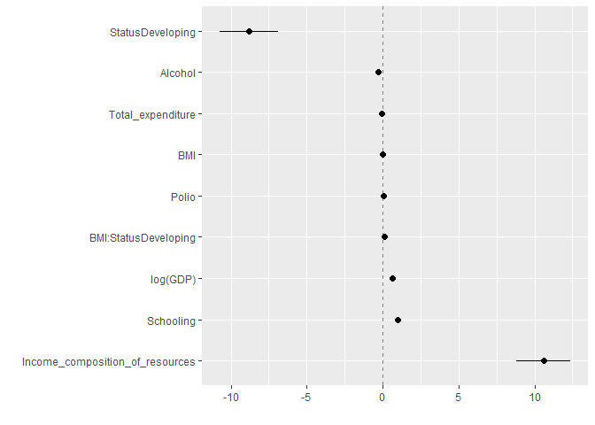

```r
tidy(mod6) %>%
  arrange(estimate) %>%
  dwplot(dot_args = list(size = 2, color = "black"),
         whisker_args = list(color = "black"),
         vline = geom_vline(xintercept = 0, colour = "grey50", linetype = 2))
```

# Stepwise Regression

Sometimes you go into an analysis with variables in mind that you want to explore. You’ve done the research and you know the relationships that might be important. However, sometimes you have a dataset that is not easily understood. In this case, stepwise regression may be a good first step. Stepwise regression using a metric (AIC, RMSE, etc) to add or take away variables from a model to make the best model possible.

Use caution when using stepwise regression methods. Make sure to double check that the variables chosen make clinical/scientific/sociological sense. You also want to make sure you have properly cleaned your data and removed any variables from your data that you do not want to end up in the final model.

Stepwise regression should be used mostly as a starting place and not as a final model. Use it to test theories, not to finish your analysis.

The `stepAIC` function from the `MASS` package allows you to create models based off of the lowest possible AIC.

Let’s first clean up our dataset a bit.

```r
le_test <- le %>% drop_na() %>% dplyr::select(-Country)
```

```r
  full.model <- lm(Life_expectancy ~., data = dplyr::select(le_test, -Year))
```

We then use the `stepAIC` function on the full model. We can specify whether we want to start with an empty model and add variables one at a time (forward), we can specify whether we want to start with a full model and remove variables one at a time (backwards), or we can do a combination of both (both).

```r
step.model <- stepAIC(full.model, direction = "both",
                      trace = FALSE)

step.model$model
```

[output not shown]

[output cut: 6585 more lines]

```r
mod7 <- lm(Life_expectancy ~., data = step.model$model)
modCheck(mod7)
```

```
##
## Call:
## lm(formula = Life_expectancy ~ ., data = step.model$model)
##
## Residuals:
##     Min      1Q  Median      3Q     Max
## -16.940  -2.076  -0.011   2.266  11.797
##
## Coefficients:
##                                   Estimate Std. Error t value Pr(>|t|)
## (Intercept)                      5.439e+01  8.263e-01  65.820  < 2e-16 ***
## StatusDeveloping                -9.798e-01  3.367e-01  -2.910  0.00366 **
## Adult_Mortality                 -1.663e-02  9.473e-04 -17.554  < 2e-16 ***
## infant_deaths                    9.072e-02  9.966e-03   9.102  < 2e-16 ***
## Alcohol                         -9.178e-02  3.301e-02  -2.780  0.00549 **
## percentage_expenditure           4.199e-04  5.943e-05   7.065 2.37e-12 ***
## Hepatitis_B                     -6.433e-03  4.439e-03  -1.449  0.14752
## BMI                              3.411e-02  5.952e-03   5.731 1.19e-08 ***
## under_five_deaths               -6.876e-02  7.403e-03  -9.289  < 2e-16 ***
## Polio                            7.861e-03  5.135e-03   1.531  0.12599
## Total_expenditure                7.659e-02  4.056e-02   1.888  0.05920 .
## Diphtheria                       1.485e-02  5.916e-03   2.511  0.01214 *
## HIV_AIDS                        -4.372e-01  1.782e-02 -24.540  < 2e-16 ***
## thinness_5_9_years              -5.601e-02  2.641e-02  -2.121  0.03411 *
## Income_composition_of_resources  9.848e+00  8.285e-01  11.886  < 2e-16 ***
## Schooling                        8.686e-01  5.887e-02  14.754  < 2e-16 ***
## ---
## Signif. codes:  0 '***' 0.001 '**' 0.01 '*' 0.05 '.' 0.1 ' ' 1
##
## Residual standard error: 3.584 on 1633 degrees of freedom
## Multiple R-squared:  0.8355, Adjusted R-squared:  0.834
## F-statistic: 552.9 on 15 and 1633 DF,  p-value: < 2.2e-16
##
## # A tibble: 16 x 5
##    term                             estimate std.error statistic   p.value
##    <chr>                               <dbl>     <dbl>     <dbl>     <dbl>
##  1 (Intercept)                     54.4      0.826         65.8  0.
##  2 StatusDeveloping                -0.980    0.337         -2.91 3.66e-  3
##  3 Adult_Mortality                 -0.0166   0.000947     -17.6  2.49e- 63
##  4 infant_deaths                    0.0907   0.00997        9.10 2.50e- 19
##  5 Alcohol                         -0.0918   0.0330        -2.78 5.49e-  3
##  6 percentage_expenditure           0.000420 0.0000594      7.07 2.37e- 12
##  7 Hepatitis_B                     -0.00643  0.00444       -1.45 1.48e-  1
##  8 BMI                              0.0341   0.00595        5.73 1.19e-  8
##  9 under_five_deaths               -0.0688   0.00740       -9.29 4.82e- 20
## 10 Polio                            0.00786  0.00513        1.53 1.26e-  1
## 11 Total_expenditure                0.0766   0.0406         1.89 5.92e-  2
## 12 Diphtheria                       0.0149   0.00592        2.51 1.21e-  2
## 13 HIV_AIDS                        -0.437    0.0178       -24.5  1.85e-113
## 14 thinness_5_9_years              -0.0560   0.0264        -2.12 3.41e-  2
## 15 Income_composition_of_resources  9.85     0.828         11.9  2.61e- 31
## 16 Schooling                        0.869    0.0589        14.8  2.44e- 46
## # A tibble: 1 x 12
##   r.squared adj.r.squared sigma statistic p.value    df logLik   AIC   BIC
##       <dbl>         <dbl> <dbl>     <dbl>   <dbl> <dbl>  <dbl> <dbl> <dbl>
## 1     0.835         0.834  3.58      553.       0    15 -4437. 8908. 9000.
## # ... with 3 more variables: deviance <dbl>, df.residual <int>, nobs <int>
```

Let’s take a look at forwards and backwards.

```r
step.model <- stepAIC(full.model, direction = "forward",
                      trace = FALSE,
                      scope = list(lower = ~1))

step.model$model
```

[output not shown]

[output cut: 8235 more lines]

```r
modCheck(lm(Life_expectancy ~., data = step.model$model))
```

```
##
## Call:
## lm(formula = Life_expectancy ~ ., data = step.model$model)
##
## Residuals:
##      Min       1Q   Median       3Q      Max
## -16.9597  -2.0621  -0.0147   2.2751  11.7115
##
## Coefficients:
##                                   Estimate Std. Error t value Pr(>|t|)
## (Intercept)                      5.445e+01  8.400e-01  64.822  < 2e-16 ***
## StatusDeveloping                -9.684e-01  3.379e-01  -2.865  0.00422 **
## Adult_Mortality                 -1.663e-02  9.494e-04 -17.517  < 2e-16 ***
## infant_deaths                    9.350e-02  1.065e-02   8.777  < 2e-16 ***
## Alcohol                         -9.140e-02  3.316e-02  -2.756  0.00592 **
## percentage_expenditure           3.673e-04  1.801e-04   2.040  0.04156 *
## Hepatitis_B                     -6.525e-03  4.449e-03  -1.467  0.14265
## Measles                         -7.865e-06  1.079e-05  -0.729  0.46597
## BMI                              3.376e-02  5.998e-03   5.628 2.15e-08 ***
## under_five_deaths               -7.035e-02  7.711e-03  -9.123  < 2e-16 ***
## Polio                            7.935e-03  5.152e-03   1.540  0.12370
## Total_expenditure                7.586e-02  4.067e-02   1.865  0.06236 .
## Diphtheria                       1.490e-02  5.928e-03   2.513  0.01205 *
## HIV_AIDS                        -4.370e-01  1.784e-02 -24.490  < 2e-16 ***
## GDP                              8.738e-06  2.837e-05   0.308  0.75813
## Population                      -6.425e-10  1.749e-09  -0.367  0.71337
## thinness__1_19_years            -1.238e-02  5.300e-02  -0.234  0.81527
## thinness_5_9_years              -4.798e-02  5.231e-02  -0.917  0.35917
## Income_composition_of_resources  9.817e+00  8.321e-01  11.797  < 2e-16 ***
## Schooling                        8.665e-01  5.940e-02  14.587  < 2e-16 ***
## ---
## Signif. codes:  0 '***' 0.001 '**' 0.01 '*' 0.05 '.' 0.1 ' ' 1
##
## Residual standard error: 3.588 on 1629 degrees of freedom
## Multiple R-squared:  0.8356, Adjusted R-squared:  0.8336
## F-statistic: 435.7 on 19 and 1629 DF,  p-value: < 2.2e-16
##
## # A tibble: 20 x 5
##    term                             estimate     std.error statistic   p.value
##    <chr>                               <dbl>         <dbl>     <dbl>     <dbl>
```

[output cut: 10 more lines]

```
## 11 Polio                            7.94e- 3 0.00515           1.54  1.24e-  1
## 12 Total_expenditure                7.59e- 2 0.0407            1.87  6.24e-  2
## 13 Diphtheria                       1.49e- 2 0.00593           2.51  1.21e-  2
## 14 HIV_AIDS                        -4.37e- 1 0.0178          -24.5   4.93e-113
## 15 GDP                              8.74e- 6 0.0000284         0.308 7.58e-  1
## 16 Population                      -6.42e-10 0.00000000175    -0.367 7.13e-  1
## 17 thinness__1_19_years            -1.24e- 2 0.0530           -0.234 8.15e-  1
## 18 thinness_5_9_years              -4.80e- 2 0.0523           -0.917 3.59e-  1
## 19 Income_composition_of_resources  9.82e+ 0 0.832            11.8   7.02e- 31
## 20 Schooling                        8.67e- 1 0.0594           14.6   2.17e- 45
## # A tibble: 1 x 12
##   r.squared adj.r.squared sigma statistic p.value    df logLik   AIC   BIC
##       <dbl>         <dbl> <dbl>     <dbl>   <dbl> <dbl>  <dbl> <dbl> <dbl>
## 1     0.836         0.834  3.59      436.       0    19 -4436. 8915. 9029.
## # ... with 3 more variables: deviance <dbl>, df.residual <int>, nobs <int>
```

```r
step.model <- stepAIC(full.model, direction = "backward",
                      trace = FALSE)
```

## Logistic Regression

When we have an outcome that is binary, we want to move onto logistic regression. For this we are going to be using the following dataset:

From: Davide Chicco, Giuseppe Jurman: “Machine learning can predict survival of patients with heart failure from serum creatinine and ejection fraction alone”. BMC Medical Informatics and Decision Making 20, 16 (2020).

- age: age of the patient (years)
- anaemia: decrease of red blood cells or hemoglobin (boolean)
- high blood pressure: if the patient has hypertension (boolean)
- creatinine phosphokinase (CPK): level of the CPK enzyme in the blood (mcg/L)
- diabetes: if the patient has diabetes (boolean)
- ejection fraction: percentage of blood leaving the heart at each contraction (percentage)
- platelets: platelets in the blood (kiloplatelets/mL)
- sex: woman or man (binary)
- serum creatinine: level of serum creatinine in the blood (mg/dL)
- serum sodium: level of serum sodium in the blood (mEq/L)
- smoking: if the patient smokes or not (boolean)
- time: follow-up period (days)
- [target] death event: if the patient deceased during the follow-up period (boolean)

Let’s read in the data and take a look at our outcome variable `DEATH_EVENT`

```r
hf <- read_csv("heart_failure_clinical_records_dataset.csv")
hf %>% count(DEATH_EVENT)
```

```
## # A tibble: 2 x 2
##   DEATH_EVENT     n
##         <dbl> <int>
## 1           0   203
## 2           1    96
```

# Visualizing the data

## Continuous data Exploration

The first thing we are going to do is explore the continuous data variables that might be important. However, we first want to turn `DEATH_EVENT` into a factor variable as the modeling tool we will use prefers the outcome to be a binary factor.

```r
hf$DEATH_EVENT <- factor(hf$DEATH_EVENT)
```

Let’s start by looking at Age as a possibly important variable in a `DEATH_EVENT`.

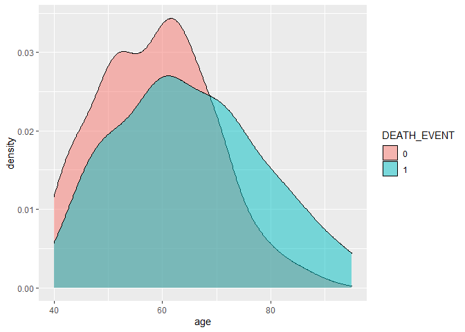

```r
# Age
hf %>%
  ggplot(aes(x = age)) + geom_density(aes(fill = DEATH_EVENT), alpha = .5)
```

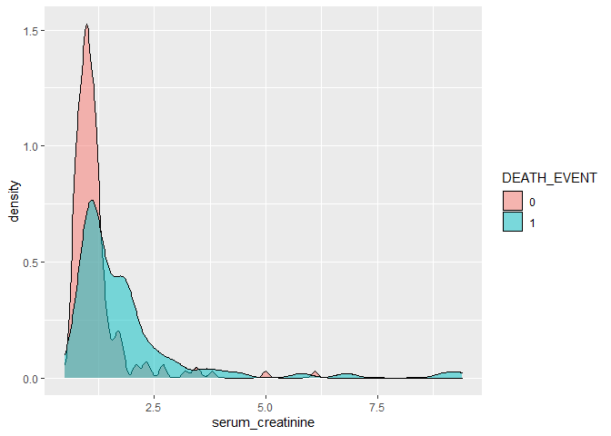

```r
# DEATH EVENT tends to occur more often in older individuals.

# serum creatinine: level of serum creatinine in the blood (mg/dL)
hf %>%
  ggplot(aes(x = serum_creatinine)) + geom_density(aes(fill = DEATH_EVENT), alpha = .5)
```

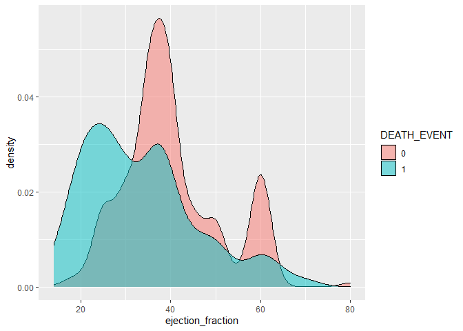

```r
# ejection fraction: percentage of blood leaving the heart at each contraction (percentage)
hf %>%
  ggplot(aes(x = ejection_fraction)) + geom_density(aes(fill = DEATH_EVENT), alpha = .5)
```

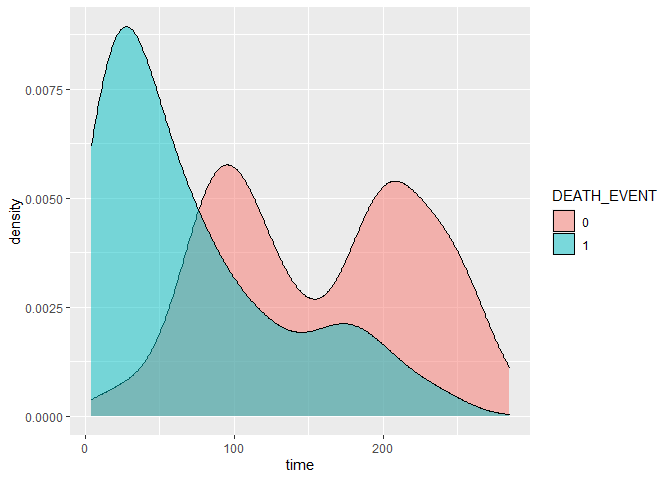

```r
# time: follow-up period (days)
# This would be useful for a survival analysis...
hf %>%
  ggplot(aes(x = time)) + geom_density(aes(fill = DEATH_EVENT), alpha = .5)
```

```r
names(hf)
```

```
##  [1] "age"                      "anaemia"
##  [3] "creatinine_phosphokinase" "diabetes"
##  [5] "ejection_fraction"        "high_blood_pressure"
##  [7] "platelets"                "serum_creatinine"
##  [9] "serum_sodium"             "sex"
## [11] "smoking"                  "time"
## [13] "DEATH_EVENT"
```

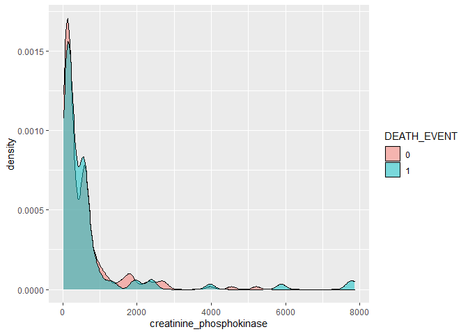

```r
# creatinine phosphokinase (CPK): level of the CPK enzyme in the blood (mcg/L)
hf %>%
  ggplot(aes(x = creatinine_phosphokinase)) + geom_density(aes(fill = DEATH_EVENT), alpha = .5)
```

## Categorical Exploration

Just like with our multivariate linear regression, we also need to look at the categorical variables.

```r
#Diabetes
tab <- xtabs(~diabetes + DEATH_EVENT, data = hf)
prop.table(tab, margin = 1)
```

```
##         DEATH_EVENT
## diabetes         0         1
##        0 0.6781609 0.3218391
##        1 0.6800000 0.3200000
```

```r
# No real difference in occurrences of Death events with or without diabetes

# What about if the patient has anaemia
tab <- xtabs(~anaemia + DEATH_EVENT, data = hf)
prop.table(tab, margin = 1)
```

```
##        DEATH_EVENT
## anaemia         0         1
##       0 0.7058824 0.2941176
##       1 0.6434109 0.3565891
```

```r
# Those with anaemia do have higher death rates

# Sex as an explanation
tab <- xtabs(~sex + DEATH_EVENT, data = hf)
prop.table(tab, margin = 1)
```

```
##    DEATH_EVENT
## sex         0         1
##   0 0.6761905 0.3238095
##   1 0.6804124 0.3195876
```

```r
# Sex does not seem to be related

# How many DEATHS overall?
hf %>%
  count(DEATH_EVENT) %>%
  mutate(prop = n / nrow(hf))
```

```
## # A tibble: 2 x 3
##   DEATH_EVENT     n  prop
##   <fct>       <int> <dbl>
## 1 0             203 0.679
## 2 1              96 0.321
```

About 32% of the patients in this dataset end up passing away.

## Running Logistic Regressions

For this we’ll use *logistic regression* to model the *log odds* of the binary response. That is, instead of modeling the outcome variable, $Y$, directly against the inputs, we’ll model the *log odds* of the outcome variable.

- If $p$ is the **probability** that a death occurs,
- then
  $$\frac{p}{1-p}$$
  is the **odds** that a death occurs
- and
  $$log(\frac{p}{1-p})$$
  is called the **log odds**

The log odds can be expressed as:

$$log(\frac{p}{1-p}) = \beta_0 + \beta_1 x_1 + \cdots + \beta_k x_k$$
Where $\beta_0$ is the intercept, $\beta_1$ is the increase in the log odds of the outcome for every unit increase in $x_1$, and so on.

Modeling the **log odds** rather than the probability or the odds has the benefit of a linear model on the right-hand side and compared to probability that is constrained between 0 and 1, log odds have a wider range.

- Probability ranges from 0 to 1
- Odds range from 0 to Inf
- Log odds range from -Inf to Inf

Logistic regression is a type of *generalized linear model* (GLM). We fit GLM models in R using the `glm()` function. It works like the `lm()` function except we specify which GLM to fit using the `family` argument. Logistic regression requires `family=binomial`.

The typical use looks like this:

```r
mod <- glm(y ~ x, data=yourdata, family='binomial')
summary(mod)
```

In R, as in most statistical software, the outcome variable must be coded as 0/1 so that is why we did that earlier.

## Just the intercept model

Looking at a model without any predictors will help us understand a bit more about the relationship between probability, odds, and log odds.

To fit a model without any predictors, we just model the outcome against 1 (the intercept).

```r
glm_mod0 <- glm(DEATH_EVENT ~ 1, data=hf, family="binomial")
summary(glm_mod0)
```

```
##
## Call:
## glm(formula = DEATH_EVENT ~ 1, family = "binomial", data = hf)
##
## Deviance Residuals:
##    Min      1Q  Median      3Q     Max
## -0.880  -0.880  -0.880   1.507   1.507
##
## Coefficients:
##             Estimate Std. Error z value Pr(>|z|)
## (Intercept)  -0.7489     0.1239  -6.046 1.49e-09 ***
## ---
## Signif. codes:  0 '***' 0.001 '**' 0.01 '*' 0.05 '.' 0.1 ' ' 1
##
## (Dispersion parameter for binomial family taken to be 1)
##
##     Null deviance: 375.35  on 298  degrees of freedom
## Residual deviance: 375.35  on 298  degrees of freedom
## AIC: 377.35
##
## Number of Fisher Scoring iterations: 4
```

So -0.7489 is the log odds of dying for this population. What does this mean? Let’s convert it to odds and to probability.

```r
# extract just the log odds
summary(glm_mod0)$coefficients[1]
```

```
## [1] -0.7488578
```

```r
# calculate the odds
exp(summary(glm_mod0)$coefficients[1])
```

```
## [1] 0.4729064
```

The odds are 0.472 to 1 that a random patient selected from this population will die.

What about the probability? Remember that odds = p / (1-p) so the probability of a death is odds / (1 + odds)

```r
0.4729064/(1+0.4729064)
```

```
## [1] 0.3210702
```

32%, same as we calculated above.

```r
hf %>%
  count(DEATH_EVENT) %>%
  mutate(prop = n / nrow(hf))
```

```
## # A tibble: 2 x 3
##   DEATH_EVENT     n  prop
##   <fct>       <int> <dbl>
## 1 0             203 0.679
## 2 1              96 0.321
```

Let’s fit a logistic regression model assessing how the odds of death change with one categorical predictor we identified in EDA as important, anaemia.

Let’s start by looking at the relationship between anaemia and a Death event occurring.

```r
log_mod1 <- glm(DEATH_EVENT ~ anaemia, data = hf, family = "binomial")
summary(log_mod1)
```

```
##
## Call:
## glm(formula = DEATH_EVENT ~ anaemia, family = "binomial", data = hf)
##
## Deviance Residuals:
##     Min       1Q   Median       3Q      Max
## -0.9391  -0.9391  -0.8346   1.4361   1.5645
##
## Coefficients:
##             Estimate Std. Error z value Pr(>|z|)
## (Intercept)  -0.8755     0.1683  -5.201 1.98e-07 ***
## anaemia       0.2853     0.2492   1.145    0.252
## ---
## Signif. codes:  0 '***' 0.001 '**' 0.01 '*' 0.05 '.' 0.1 ' ' 1
##
## (Dispersion parameter for binomial family taken to be 1)
##
##     Null deviance: 375.35  on 298  degrees of freedom
## Residual deviance: 374.04  on 297  degrees of freedom
## AIC: 378.04
##
## Number of Fisher Scoring iterations: 4
```

The intercept corresponds to the log odds of death for someone without anaemia (-.8755).

The next coefficient is the log odds of death for someone with anaemia (.2853). Let’s calculate the odds ratio for these.

```r
exp(summary(log_mod1)$coefficients)
```

```
##              Estimate Std. Error     z value Pr(>|z|)
## (Intercept) 0.4166667   1.183321 0.005510708 1.000000
## anaemia     1.3301205   1.283050 3.141050074 1.287101
```

So 1.33:1 that someone with anaemia in this population will die compared to someone without. We can phrase it the other way as well: The odds are 0.42:1 that someone without anaemia will die, but it is much more conventional to interpret whichever odds is > 1.

Let’s calculate 95% confidence intervals to get some estimate of the variability.

```r
exp(cbind(OR = coef(log_mod1), confint(log_mod1)))
```

```
##                    OR     2.5 %    97.5 %
## (Intercept) 0.4166667 0.2971043 0.5756451
## anaemia     1.3301205 0.8154214 2.1697997
```

Note that the confidence interval crosses 1, which indicates a lack of significance.

What else can we learn from the output?

```r
summary(log_mod1)
```

```
##
## Call:
## glm(formula = DEATH_EVENT ~ anaemia, family = "binomial", data = hf)
##
## Deviance Residuals:
##     Min       1Q   Median       3Q      Max
## -0.9391  -0.9391  -0.8346   1.4361   1.5645
##
## Coefficients:
##             Estimate Std. Error z value Pr(>|z|)
## (Intercept)  -0.8755     0.1683  -5.201 1.98e-07 ***
## anaemia       0.2853     0.2492   1.145    0.252
## ---
## Signif. codes:  0 '***' 0.001 '**' 0.01 '*' 0.05 '.' 0.1 ' ' 1
##
## (Dispersion parameter for binomial family taken to be 1)
##
##     Null deviance: 375.35  on 298  degrees of freedom
## Residual deviance: 374.04  on 297  degrees of freedom
## AIC: 378.04
##
## Number of Fisher Scoring iterations: 4
```

Notice that for logistic regression, we no longer have R^2 as a metric of model fit. Instead we have deviance and the AIC, Aikaike Information Criterion. The AIC alone is not interpretable, but it is useful for comparing nested models. If you would like to use model selection in your research, please reach out to us for help with this if desired.

We can calculate a sort of pseudo-R^2 in the explained deviance, which is
$$1 - \frac{Residual Deviance}{Null Deviance}$$

```r
1-(log_mod1$deviance/log_mod1$null.deviance)
```

```
## [1] 0.003486293
```

```r
devCheck <- function(mod) {
  print(tidy(mod))
  print(exp(cbind(OR = coef(mod), confint(mod))))
  print(paste("Model Fit:", round(1-(mod$deviance/mod$null.deviance), 5)))
}

devCheck(log_mod1)
```

```
## # A tibble: 2 x 5
##   term        estimate std.error statistic     p.value
##   <chr>          <dbl>     <dbl>     <dbl>       <dbl>
## 1 (Intercept)   -0.875     0.168     -5.20 0.000000198
## 2 anaemia        0.285     0.249      1.14 0.252
```

```
##                    OR     2.5 %    97.5 %
## (Intercept) 0.4166667 0.2971043 0.5756451
## anaemia     1.3301205 0.8154214 2.1697997
## [1] "Model Fit: 0.00349"
```

Anaemia did not prove to be consequential, let’s check Age.

```r
log_mod2 <- glm(DEATH_EVENT ~ age, data = hf, family = "binomial")
devCheck(log_mod2)
```

```
## # A tibble: 2 x 5
##   term        estimate std.error statistic     p.value
##   <chr>          <dbl>     <dbl>     <dbl>       <dbl>
## 1 (Intercept)  -3.65      0.707      -5.17 0.000000232
## 2 age           0.0469    0.0111      4.24 0.0000223
```

```
##                     OR      2.5 %     97.5 %
## (Intercept) 0.02587886 0.00620156 0.09979039
## age         1.04806947 1.02602488 1.07168816
## [1] "Model Fit: 0.05157"
```

Essentially here the odds of someone dying increases by 1.05:1 each year, or by 5%.

```r
log_mod3 <- glm(DEATH_EVENT ~ age + ejection_fraction, data = hf, family = "binomial")
devCheck(log_mod3)
```

```
## # A tibble: 3 x 5
##   term              estimate std.error statistic    p.value
##   <chr>                <dbl>     <dbl>     <dbl>      <dbl>
## 1 (Intercept)        -1.79      0.800      -2.24 0.0248
## 2 age                 0.0558    0.0118      4.72 0.00000241
## 3 ejection_fraction  -0.0659    0.0135     -4.87 0.00000113
```

```
##                          OR      2.5 %    97.5 %
## (Intercept)       0.1661441 0.03381588 0.7859550
## age               1.0574074 1.03374437 1.0830121
## ejection_fraction 0.9362606 0.91069761 0.9604511
## [1] "Model Fit: 0.12774"
```

```r
log_mod4 <- glm(DEATH_EVENT ~ age + ejection_fraction + serum_creatinine, data = hf, family = "binomial")
devCheck(log_mod4)
```

```
## # A tibble: 4 x 5
##   term              estimate std.error statistic     p.value
##   <chr>                <dbl>     <dbl>     <dbl>       <dbl>
## 1 (Intercept)        -2.35      0.840      -2.80 0.00507
## 2 age                 0.0517    0.0123      4.20 0.0000265
## 3 ejection_fraction  -0.0700    0.0142     -4.92 0.000000872
## 4 serum_creatinine    0.666     0.159       4.18 0.0000286
```

```
##                           OR      2.5 %    97.5 %
## (Intercept)       0.09507732 0.01775138 0.4827603
## age               1.05309516 1.02851218 1.0795577
## ejection_fraction 0.93239467 0.90568697 0.9578092
## serum_creatinine  1.94628652 1.45900885 2.7602963
## [1] "Model Fit: 0.18667"
```

#### Visualize the model

Let’s create a visualization showing several curves, showing various levels of ejection fraction over different ages

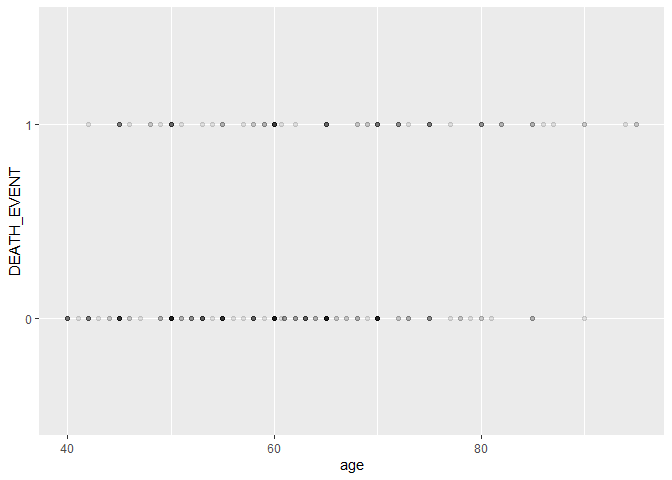

```r
ggplot() +
  geom_point(data = hf, aes(age, DEATH_EVENT), alpha = .1)
```

And now we generate the predicted values using `data_grid()` and `add_predictions()` as before

```r
newdata2 <- data_grid(hf, age, ejection_fraction)
newdata2 <- add_predictions(newdata2, log_mod3, type = "response")
newdata2
```

```
## # A tibble: 799 x 3
##      age ejection_fraction   pred
##    <dbl>             <dbl>  <dbl>
##  1    40                14 0.381
##  2    40                15 0.366
##  3    40                17 0.336
##  4    40                20 0.293
##  5    40                25 0.230
##  6    40                30 0.177
##  7    40                35 0.134
##  8    40                38 0.113
##  9    40                40 0.100
## 10    40                45 0.0741
## # ... with 789 more rows
```

Now we are looking at the probability of the DEATH EVENT by age and ejection fraction

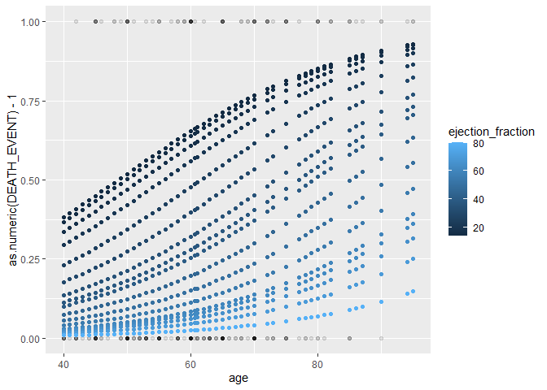

```r
ggplot() +
  geom_point(data = hf, aes(age, as.numeric(DEATH_EVENT) - 1), alpha = .1) +
  geom_point(data = newdata2, aes(age, pred, color = ejection_fraction))
```

# Resources for Logistic Regression

- [IDRE Stats](https://stats.idre.ucla.edu/r/dae/logit-regression/)
- [OpenIntro](https://www.openintro.org/stat/textbook.php?stat_book=os). A wonderful introductory statistics textbook free to download (or for a suggested donation of $15)
- Alan Agresti’s [*Categorical Data Analysis*](https://www.amazon.com/Categorical-Data-Analysis-Alan-Agresti/dp/0470463635/ref=sr_1_1?ie=UTF8&qid=1473180895&sr=8-1&keywords=categorical+data+analysis&tag=gettgenedone-20) has long been considered the definitive text on this topic.
- I also recommend Agresti’s [*Introduction to Categorical Data Analysis*](https://www.amazon.com/Introduction-Categorical-Data-Analysis/dp/0471226181/ref=sr_1_3?ie=UTF8&qid=1473180895&sr=8-3&keywords=categorical+data+analysis&tag=gettgenedone-20) (a.k.a. “Agresti lite”) for a gentler introduction.